# Project (Neural Network)

## Objective

The objective of the project is to learn how to implement a simple image classification pipeline based on a deep neural network.

### Context

Recognizing multi-digit numbers in photographs captured at street level is an important component of modern-day map making. A classic example of a corpus of such street level photographs is Google’s Street View imagery comprised of hundreds of millions of geo-located 360 degree panoramic images. The ability to automatically transcribe an address number from a geo-located patch of pixels and associate the transcribed number with a known street address helps pinpoint, with a high degree of accuracy, the location of the building it represents.

More broadly, recognizing numbers in photographs is a problem of interest to the optical character recognition community. While OCR on constrained domains like document processing is well studied, arbitrary multi-character text recognition in photographs is still highly challenging. This difficulty arises due to the wide variability in the visual appearance of text in the wild on account of a large range of fonts, colours, styles, orientations, and character arrangements. The recognition problem is further complicated by environmental factors such as lighting, shadows, secularities, and occlusions as well as by image acquisition factors such as resolution, motion, and focus blurs.

In this project we will use dataset with images centred around a single digit (many of the images do contain some distractors at the sides). Although we are taking a sample of the data which is simpler, it is more complex than MNIST because of the distractors.

### Steps:

1. Load Dataset
2. Understand the basic Image Classification pipeline and the data-driven approach (train/predict stages)
3. Data fetching and understand the train/val/test splits. (15 points)
4. Implement and apply a deep neural network classifier including (feedforward neural network, RELU, activations) (25 points)
5. Implement batch normalization for training the neural network(10 points)
6. Print the classification accuracy metrics (10 points)

## Step 0 - Import Libraries

```python
#Imports Basic Libraries
import pandas as pd, numpy as np, matplotlib.pyplot as plt, seaborn as sns, h5py
import matplotlib.style as style; style.use('fivethirtyeight')

#Metrics and Preprocessing
from sklearn.metrics import classification_report, accuracy_score, confusion_matrix, precision_score, recall_score, f1_score, precision_recall_curve, auc
from sklearn.model_selection import train_test_split
from sklearn import preprocessing
from sklearn import metrics

#TensorFlow and Keras
from keras.models import Sequential
from keras.utils.np_utils import to_categorical
from keras.layers import Activation, Dense
from keras.layers import BatchNormalization, Dropout
from keras import optimizers

import warnings
warnings.filterwarnings('ignore')

#To enable plotting graphs in Jupyter notebook
%matplotlib inline
```

```python
#Checking if GPU is found
import tensorflow as tf
device_name = tf.test.gpu_device_name()
if device_name != '/device:GPU:0':
  print('GPU Device Not Found')
```

## Step 1, 2, 3

```python
#Open the file as readonly from Google Drive
from google.colab import drive
drive.mount('/content/drive')
```

```python
h5_master=h5py.File("/content/drive/My Drive/My Files/Data/SVHN_single_grey1.h5",'r')
```

```python
#Data keys
h5_master.keys()
```

```
<KeysViewHDF5 ['X_test', 'X_train', 'X_val', 'y_test', 'y_train', 'y_val']>
```

```python
#Load the training, testing, and validation data
X_train = h5_master['X_train']
X_test = h5_master['X_test']
X_val = h5_master['X_val']
y_train = h5_master['y_train']
y_test = h5_master['y_test']
y_val = h5_master['y_val']
```

```python
#Printing the shape of training, testing, and validation data
print("==============================================")
print("X Training Data Shape :", X_train.shape)
print("X Testing Data Shape :", X_test.shape)
print("X Validation Data Shape :", X_val.shape)
print("==============================================")
print("Y Training Data Shape :", y_train.shape)
print("Y Testing Data Shape :", y_test.shape)
print("Y Validation Data Shape :", y_val.shape)
print("==============================================")
print('Unique Labels in Y_train:', np.unique(y_train))
print('Unique Labels in Y_test:', np.unique(y_test))
print('Unique Labels in Y_val:', np.unique(y_val))
print("==============================================")
```

```
==============================================
X Training Data Shape : (42000, 32, 32)
X Testing Data Shape : (18000, 32, 32)
X Validation Data Shape : (60000, 32, 32)
==============================================
Y Training Data Shape : (42000,)
Y Testing Data Shape : (18000,)
Y Validation Data Shape : (60000,)
==============================================
Unique Labels in Y_train: [0 1 2 3 4 5 6 7 8 9]
Unique Labels in Y_test: [0 1 2 3 4 5 6 7 8 9]
Unique Labels in Y_val: [0 1 2 3 4 5 6 7 8 9]
==============================================
```

#### Observations

- Length of Training Sets: 42k, Validation Sets: 60k, Test Sets: 18k
- Size of the Images: 32*32
- Number of Classes: 10

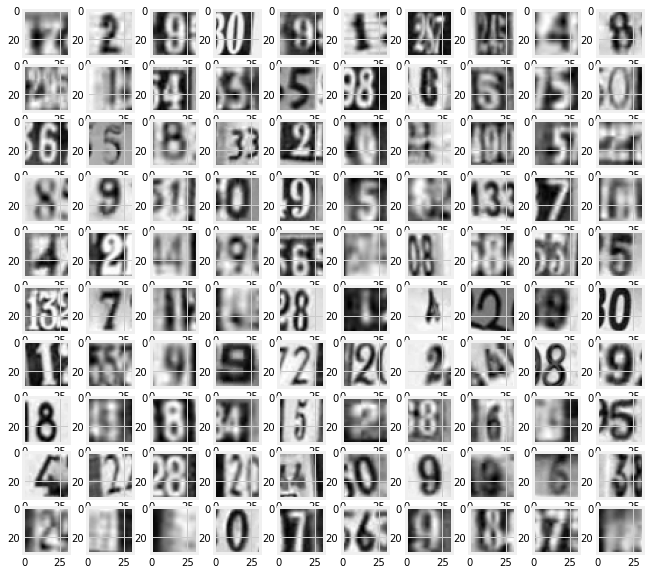

```python
#Visualizing the dataset
fig = plt.figure(figsize=(10,10))
columns = 10
rows = 10
for i in range(1, columns * rows + 1):
    img = X_test[i]
    fig.add_subplot(rows, columns, i)
    plt.imshow(img, cmap='gray')
plt.show()
```

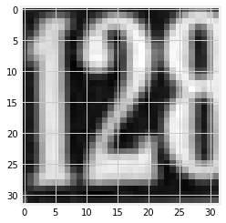

```
Label:  2
```

```python
#Show the number in the dataset
plt.imshow(X_train[0], cmap='gray')
plt.show()
print("Label: ", y_train[0])
```

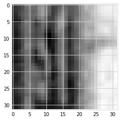

```
Label:  1
```

```python
#Show the number in the dataset
plt.imshow(X_test[0], cmap='gray')
plt.show()
print("Label: ", y_test[0])
```

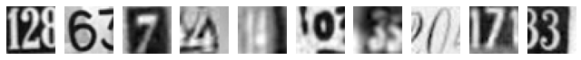

```
Label for each of the above image: [2 6 7 4 4 0 3 0 7 3]
```

```python
#Visualizing the first 10 images in the dataset and their labels
%matplotlib inline
import matplotlib.pyplot as plt
plt.figure(figsize=(10, 1))
for i in range(10):
    plt.subplot(1, 10, i+1)
    plt.imshow(X_train[i].reshape(32,32),cmap='gray')
    plt.axis('off')
plt.show()
print('Label for each of the above image: %s' % (y_train[0:10]))
```

## Step 4 - Implement and apply a deep neural network classifier including (feedforward neural network, RELU, activations) (25 points)

```python
#Reshape data from 2D to 1D -> 32X32 to 1024
X_train = np.asarray(X_train).reshape(42000,1024).astype('float32')
X_test = np.asarray(X_test).reshape(18000,1024).astype('float32')
X_val = np.asarray(X_val).reshape(60000,1024).astype('float32')

X_train = X_train/255
X_test = X_test/255
X_val = X_val/255
```

```python
y_train = tf.keras.utils.to_categorical(y_train, num_classes=10)
y_test = tf.keras.utils.to_categorical(y_test, num_classes=10)
y_val = tf.keras.utils.to_categorical(y_val, num_classes=10)
```

```python
print(X_train.shape, X_test.shape, X_val.shape, y_train.shape, y_test.shape, y_val.shape)
```

```
(42000, 1024) (18000, 1024) (60000, 1024) (42000, 10) (18000, 10) (60000, 10)
```

```python
#Initialize the Artificial Neural Network Classifier
keras_model1 = Sequential()
```

```python
#==============
#Input Layer
#==============
#Adding Input layer and activation functions ReLU
keras_model1.add(Dense(512, input_shape=(1024, )))
#Adding Activation function
keras_model1.add(Activation('sigmoid'))

#==============
#Hidden Layer 1
#==============
#Adding Hidden layer
keras_model1.add(Dense(256))
#Adding Activation function
keras_model1.add(Activation('sigmoid'))

#==============
#Hidden Layer 2
#==============
#Adding Hidden layer
keras_model1.add(Dense(128))
#Adding Activation function
keras_model1.add(Activation('sigmoid'))

#==============
#Hidden Layer 3
#==============
#Adding Hidden layer
keras_model1.add(Dense(64))
#Adding Activation function
keras_model1.add(Activation('sigmoid'))

#==============
#Hidden Layer 4
#==============
#Adding Hidden layer
keras_model1.add(Dense(32))
#Adding Activation function
keras_model1.add(Activation('sigmoid'))

#==============
#Output Layer
#==============
#Adding output layer which is of 10 nodes (digits)
keras_model1.add(Dense(10))
#Adding Activation function
#Here, we are using softmax function because we have multiclass classsification
keras_model1.add(Activation('softmax'))
```

```python
#Model Summary
keras_model1.summary()
```

```
Model: "sequential_1"
_________________________________________________________________
Layer (type)                 Output Shape              Param #
=================================================================
dense_1 (Dense)              (None, 512)               524800
_________________________________________________________________
activation_1 (Activation)    (None, 512)               0
_________________________________________________________________
dense_2 (Dense)              (None, 256)               131328
_________________________________________________________________
activation_2 (Activation)    (None, 256)               0
_________________________________________________________________
dense_3 (Dense)              (None, 128)               32896
_________________________________________________________________
activation_3 (Activation)    (None, 128)               0
_________________________________________________________________
dense_4 (Dense)              (None, 64)                8256
_________________________________________________________________
activation_4 (Activation)    (None, 64)                0
_________________________________________________________________
dense_5 (Dense)              (None, 32)                2080
_________________________________________________________________
activation_5 (Activation)    (None, 32)                0
_________________________________________________________________
dense_6 (Dense)              (None, 10)                330
_________________________________________________________________
activation_6 (Activation)    (None, 10)                0
=================================================================
Total params: 699,690
Trainable params: 699,690
Non-trainable params: 0
_________________________________________________________________
```

#### NN Model with Sigmoid Activation and SGD Optimizer

```python
sgd = optimizers.SGD(lr = 0.01)
keras_model1.compile(optimizer=sgd, loss='categorical_crossentropy', metrics=['accuracy'])
history1 = keras_model1.fit(X_train, y_train, validation_data=(X_val, y_val), batch_size=1000, epochs=100, verbose=1)
```

```
Train on 42000 samples, validate on 60000 samples
```

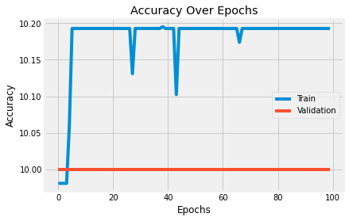

```python
plt.plot(np.array(history1.history['accuracy']) * 100)
plt.plot(np.array(history1.history['val_accuracy']) * 100)
plt.ylabel('Accuracy')
plt.xlabel('Epochs')
plt.legend(['Train', 'Validation'])
plt.title('Accuracy Over Epochs')
plt.show()
```

```python
results1 = keras_model1.evaluate(X_val, y_val)

df_temp = pd.DataFrame({'Method':['NN, SGD, Sigmoid, LR=0.01'], 'Validation Accuracy':
                        [results1[1]], 'Test Accuracy':[0.0]}, index={'1'})
df_result = df_temp.copy()
df_result
```

|  | Method | Validation Accuracy | Test Accuracy |
| --- | --- | --- | --- |
| 1 | NN, SGD, Sigmoid, LR=0.01 | 0.1 | 0.0 |

```python
#Changing Learning Rate
sgd = optimizers.SGD(lr = 0.001)
keras_model1.compile(optimizer=sgd, loss='categorical_crossentropy', metrics=['accuracy'])
history2 = keras_model1.fit(X_train, y_train, validation_data=(X_val, y_val), batch_size=1000, epochs=100, verbose=1)
```

```
Train on 42000 samples, validate on 60000 samples
```

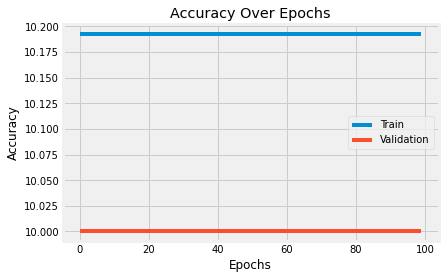

```python
plt.plot(np.array(history2.history['accuracy']) * 100)
plt.plot(np.array(history2.history['val_accuracy']) * 100)
plt.ylabel('Accuracy')
plt.xlabel('Epochs')
plt.legend(['Train', 'Validation'])
plt.title('Accuracy Over Epochs')
plt.show()
```

```python
results1 = keras_model1.evaluate(X_val, y_val)

df_temp = pd.DataFrame({'Method':['NN, SGD, Sigmoid, LR=0.001'], 'Validation Accuracy':
                        [results1[1]], 'Test Accuracy':[0.0]}, index={'2'})
df_result = pd.concat([df_temp, df_result])
df_result
```

|  | Method | Validation Accuracy | Test Accuracy |
| --- | --- | --- | --- |
| 2 | NN, SGD, Sigmoid, LR=0.001 | 0.1 | 0.0 |
| 1 | NN, SGD, Sigmoid, LR=0.01 | 0.1 | 0.0 |

#### Observations

- Validation score is very low with Sigmoid activation, changing learning rate doesn't help.
- Optimizing the network in order to better learn the patterns in the dataset.
- Best model out of the above is the one with lower learning rate using SGD optimizer and sigmoid activations.
- Next, let's use relu activations and see if the score improves.

#### NN Model with RELU Activation and SGD Optimizer

```python
#Initialize the Artificial Neural Network Classifier
keras_model2 = Sequential()
```

```python
#==============
#Input Layer
#==============
#Adding Input layer and activation functions ReLU
keras_model2.add(Dense(512, input_shape=(1024, )))
#Adding Activation function
keras_model2.add(Activation('relu'))

#==============
#Hidden Layer 1
#==============
#Adding Hidden layer
keras_model2.add(Dense(256))
#Adding Activation function
keras_model2.add(Activation('relu'))

#==============
#Hidden Layer 2
#==============
#Adding Hidden layer
keras_model2.add(Dense(128))
#Adding Activation function
keras_model2.add(Activation('relu'))

#==============
#Hidden Layer 3
#==============
#Adding Hidden layer
keras_model2.add(Dense(64))
#Adding Activation function
keras_model2.add(Activation('relu'))

#==============
#Hidden Layer 4
#==============
#Adding Hidden layer
keras_model2.add(Dense(32))
#Adding Activation function
keras_model2.add(Activation('relu'))

#==============
#Output Layer
#==============
#Adding output layer which is of 10 nodes (digits)
keras_model2.add(Dense(10))
#Adding Activation function
#Here, we are using softmax function because we have multiclass classsification
keras_model2.add(Activation('softmax'))
```

```python
#Model Summary
keras_model2.summary()
```

```
Model: "sequential_2"
_________________________________________________________________
Layer (type)                 Output Shape              Param #
=================================================================
dense_7 (Dense)              (None, 512)               524800
_________________________________________________________________
activation_7 (Activation)    (None, 512)               0
_________________________________________________________________
dense_8 (Dense)              (None, 256)               131328
_________________________________________________________________
activation_8 (Activation)    (None, 256)               0
_________________________________________________________________
dense_9 (Dense)              (None, 128)               32896
_________________________________________________________________
activation_9 (Activation)    (None, 128)               0
_________________________________________________________________
dense_10 (Dense)             (None, 64)                8256
_________________________________________________________________
activation_10 (Activation)   (None, 64)                0
_________________________________________________________________
dense_11 (Dense)             (None, 32)                2080
_________________________________________________________________
activation_11 (Activation)   (None, 32)                0
_________________________________________________________________
dense_12 (Dense)             (None, 10)                330
_________________________________________________________________
activation_12 (Activation)   (None, 10)                0
=================================================================
Total params: 699,690
Trainable params: 699,690
Non-trainable params: 0
_________________________________________________________________
```

```python
sgd = optimizers.SGD(lr = 0.01)
keras_model2.compile(optimizer=sgd, loss='categorical_crossentropy', metrics=['accuracy'])
history3 = keras_model2.fit(X_train, y_train, validation_data=(X_val, y_val), batch_size=200, epochs=100, verbose=1)
```

```
Train on 42000 samples, validate on 60000 samples
```

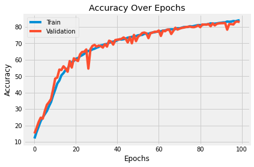

```python
plt.plot(np.array(history3.history['accuracy']) * 100)
plt.plot(np.array(history3.history['val_accuracy']) * 100)
plt.ylabel('Accuracy')
plt.xlabel('Epochs')
plt.legend(['Train', 'Validation'])
plt.title('Accuracy Over Epochs')
plt.show()
```

```python
results1 = keras_model2.evaluate(X_val, y_val)

df_temp = pd.DataFrame({'Method':['NN, SGD, RELU, LR=0.01'], 'Validation Accuracy':
                        [results1[1]], 'Test Accuracy':[0.0]}, index={'3'})
df_result = pd.concat([df_temp, df_result])
df_result
```

|  | Method | Validation Accuracy | Test Accuracy |
| --- | --- | --- | --- |
| 3 | NN, SGD, RELU, LR=0.01 | 0.829583 | 0.0 |
| 2 | NN, SGD, Sigmoid, LR=0.001 | 0.100000 | 0.0 |
| 1 | NN, SGD, Sigmoid, LR=0.01 | 0.100000 | 0.0 |

```python
#Changing Learning Rate
sgd = optimizers.SGD(lr = 0.001)
keras_model2.compile(optimizer=sgd, loss='categorical_crossentropy', metrics=['accuracy'])
#Fitting the ANN to the Training data
history4 = keras_model2.fit(X_train, y_train, validation_data=(X_val, y_val), batch_size=200, epochs=100, verbose=1)
```

```
Train on 42000 samples, validate on 60000 samples
```

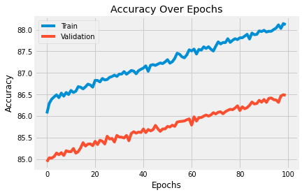

```python
plt.plot(np.array(history4.history['accuracy']) * 100)
plt.plot(np.array(history4.history['val_accuracy']) * 100)
plt.ylabel('Accuracy')
plt.xlabel('Epochs')
plt.legend(['Train', 'Validation'])
plt.title('Accuracy Over Epochs')
plt.show()
```

```python
results1 = keras_model2.evaluate(X_val, y_val)

df_temp = pd.DataFrame({'Method':['NN, SGD, RELU, LR=0.001'], 'Validation Accuracy':
                        [results1[1]], 'Test Accuracy':[0.0]}, index={'4'})
df_result = pd.concat([df_temp, df_result])
df_result
```

|  | Method | Validation Accuracy | Test Accuracy |
| --- | --- | --- | --- |
| 4 | NN, SGD, RELU, LR=0.001 | 0.864817 | 0.0 |
| 3 | NN, SGD, RELU, LR=0.01 | 0.829583 | 0.0 |
| 2 | NN, SGD, Sigmoid, LR=0.001 | 0.100000 | 0.0 |
| 1 | NN, SGD, Sigmoid, LR=0.01 | 0.100000 | 0.0 |

#### Observations

- Validation score has improved a lot with RELU activation and changing learning rate from 0.01 to 0.001 resulted into 3-4% jump in accurance.
- Lets try to check it with Adam optimizer.

#### NN Model, RELU Activations, Adam Optimizer

```python
adam = optimizers.Adam(lr = 0.01)
keras_model2.compile(optimizer=adam, loss='categorical_crossentropy', metrics=['accuracy'])
history5 = keras_model2.fit(X_train, y_train, validation_data=(X_val, y_val), batch_size=200, epochs=100, verbose=1)
```

```
Train on 42000 samples, validate on 60000 samples
```

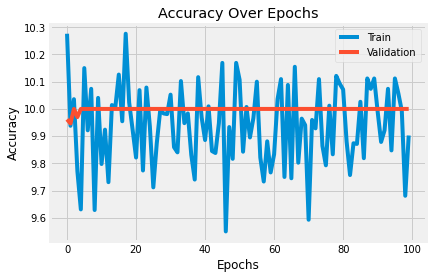

```python
plt.plot(np.array(history5.history['accuracy']) * 100)
plt.plot(np.array(history5.history['val_accuracy']) * 100)
plt.ylabel('Accuracy')
plt.xlabel('Epochs')
plt.legend(['Train', 'Validation'])
plt.title('Accuracy Over Epochs')
plt.show()
```

```python
results1 = keras_model2.evaluate(X_val, y_val)

df_temp = pd.DataFrame({'Method':['NN, Adam, RELU, LR=0.01'], 'Validation Accuracy':
                        [results1[1]], 'Test Accuracy':[0.0]}, index={'5'})
df_result = pd.concat([df_temp, df_result])
df_result
```

|  | Method | Validation Accuracy | Test Accuracy |
| --- | --- | --- | --- |
| 5 | NN, Adam, RELU, LR=0.01 | 0.100000 | 0.0 |
| 4 | NN, SGD, RELU, LR=0.001 | 0.864817 | 0.0 |
| 3 | NN, SGD, RELU, LR=0.01 | 0.829583 | 0.0 |
| 2 | NN, SGD, Sigmoid, LR=0.001 | 0.100000 | 0.0 |
| 1 | NN, SGD, Sigmoid, LR=0.01 | 0.100000 | 0.0 |

```python
#Changing Learning Rate
adam = optimizers.Adam(lr = 0.001)
keras_model2.compile(optimizer=adam, loss='categorical_crossentropy', metrics=['accuracy'])
history6 = keras_model2.fit(X_train, y_train, validation_data=(X_val, y_val), batch_size=200, epochs=100, verbose=1)
```

```
Train on 42000 samples, validate on 60000 samples
```

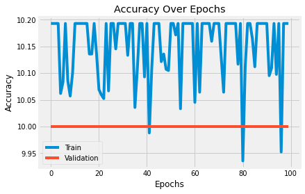

```python
plt.plot(np.array(history6.history['accuracy']) * 100)
plt.plot(np.array(history6.history['val_accuracy']) * 100)
plt.ylabel('Accuracy')
plt.xlabel('Epochs')
plt.legend(['Train', 'Validation'])
plt.title('Accuracy Over Epochs')
plt.show()
```

```python
results1 = keras_model2.evaluate(X_val, y_val)

df_temp = pd.DataFrame({'Method':['NN, Adam, RELU, LR=0.001'], 'Validation Accuracy':
                        [results1[1]], 'Test Accuracy':[0.0]}, index={'6'})
df_result = pd.concat([df_temp, df_result])
df_result
```

|  | Method | Validation Accuracy | Test Accuracy |
| --- | --- | --- | --- |
| 6 | NN, Adam, RELU, LR=0.001 | 0.100000 | 0.0 |
| 5 | NN, Adam, RELU, LR=0.01 | 0.100000 | 0.0 |
| 4 | NN, SGD, RELU, LR=0.001 | 0.864817 | 0.0 |
| 3 | NN, SGD, RELU, LR=0.01 | 0.829583 | 0.0 |
| 2 | NN, SGD, Sigmoid, LR=0.001 | 0.100000 | 0.0 |
| 1 | NN, SGD, Sigmoid, LR=0.01 | 0.100000 | 0.0 |

#### Observations

- Adam optimizer didn't result into better accurance.
- Totally resulted into worst results even after changing the learning rate from 0.01 to 0.001.
- Next, let's try the batch normalization and see if the score improves.

## Step 5 - Implement batch normalization for training the neural network(10 points)

```python
#Initialize the Artificial Neural Network Classifier
keras_model3 = Sequential()
```

```python
#==============
#Input Layer
#==============
#Adding Input layer and activation functions ReLU
keras_model3.add(Dense(512, kernel_initializer='he_normal',input_shape = (1024, )))
#Adding BatchNormalization Layer
keras_model3.add(BatchNormalization())
#Adding Activation function
keras_model3.add(Activation('relu'))

#==============
#Hidden Layer1
#==============
#Adding first Hidden layer
keras_model3.add(Dense(256, kernel_initializer='he_normal'))
#Adding BatchNormalization Layer
keras_model3.add(BatchNormalization())
#Adding Activation function
keras_model3.add(Activation('relu'))

#==============
#Hidden Layer2
#==============
#Adding second Hidden layer
keras_model3.add(Dense(128, kernel_initializer='he_normal'))
#Adding BatchNormalization Layer
keras_model3.add(BatchNormalization())
#Adding Activation function
keras_model3.add(Activation('relu'))

#==============
#Hidden Layer3
#==============
#Adding third Hidden layer
keras_model3.add(Dense(64, kernel_initializer='he_normal'))
#Adding BatchNormalization Layer
keras_model3.add(BatchNormalization())
#Adding Activation function
keras_model3.add(Activation('relu'))

#==============
#Hidden Layer4
#==============
#Adding fourth Hidden layer
keras_model3.add(Dense(32, kernel_initializer='he_normal'))
#Adding BatchNormalization Layer
keras_model3.add(BatchNormalization())
#Adding Activation function
keras_model3.add(Activation('relu'))

#==============
#Output Layer
#==============
#Adding output layer which is of 10 nodes (digidts)
keras_model3.add(Dense(10))
#Adding Activation function
#Here, we are using softmax function because we have multiclass classsification
keras_model3.add(Activation('softmax'))
```

```python
#Model Summary
keras_model3.summary()
```

```
Model: "sequential_3"
_________________________________________________________________
Layer (type)                 Output Shape              Param #
=================================================================
dense_13 (Dense)             (None, 512)               524800
_________________________________________________________________
batch_normalization_1 (Batch (None, 512)               2048
_________________________________________________________________
activation_13 (Activation)   (None, 512)               0
_________________________________________________________________
dense_14 (Dense)             (None, 256)               131328
_________________________________________________________________
batch_normalization_2 (Batch (None, 256)               1024
_________________________________________________________________
activation_14 (Activation)   (None, 256)               0
_________________________________________________________________
dense_15 (Dense)             (None, 128)               32896
_________________________________________________________________
batch_normalization_3 (Batch (None, 128)               512
_________________________________________________________________
activation_15 (Activation)   (None, 128)               0
_________________________________________________________________
dense_16 (Dense)             (None, 64)                8256
_________________________________________________________________
batch_normalization_4 (Batch (None, 64)                256
_________________________________________________________________
activation_16 (Activation)   (None, 64)                0
_________________________________________________________________
dense_17 (Dense)             (None, 32)                2080
_________________________________________________________________
batch_normalization_5 (Batch (None, 32)                128
_________________________________________________________________
activation_17 (Activation)   (None, 32)                0
_________________________________________________________________
dense_18 (Dense)             (None, 10)                330
_________________________________________________________________
activation_18 (Activation)   (None, 10)                0
=================================================================
Total params: 703,658
Trainable params: 701,674
Non-trainable params: 1,984
_________________________________________________________________
```

```python
#Setting the learning rate in the Adam
adam = optimizers.Adam(lr = 0.001)
#Compiling the NN classifier
keras_model3.compile(optimizer=adam, loss='categorical_crossentropy', metrics=['accuracy'])
#Fitting the NN to the Training data
history7 = keras_model3.fit(X_train, y_train, validation_data=(X_val,y_val), batch_size=100, epochs=100, verbose=1)
```

```
Train on 42000 samples, validate on 60000 samples
```

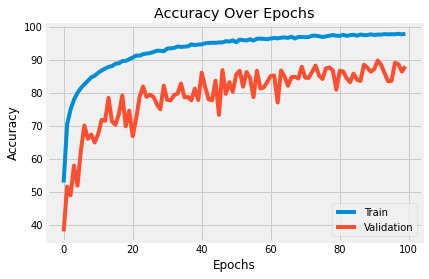

```python
plt.plot(np.array(history7.history['accuracy']) * 100)
plt.plot(np.array(history7.history['val_accuracy']) * 100)
plt.ylabel('Accuracy')
plt.xlabel('Epochs')
plt.legend(['Train', 'Validation'])
plt.title('Accuracy Over Epochs')
plt.show()
```

```python
results1 = keras_model3.evaluate(X_val, y_val)

df_temp = pd.DataFrame({'Method':['NN, Adam, RELU, Batch, LR=0.001'], 'Validation Accuracy':
                        [results1[1]], 'Test Accuracy':[0.0]}, index={'7'})
df_result = pd.concat([df_temp, df_result])
df_result
```

|  | Method | Validation Accuracy | Test Accuracy |
| --- | --- | --- | --- |
| 7 | NN, Adam, RELU, Batch, LR=0.001 | 0.879967 | 0.0 |
| 6 | NN, Adam, RELU, LR=0.001 | 0.100000 | 0.0 |
| 5 | NN, Adam, RELU, LR=0.01 | 0.100000 | 0.0 |
| 4 | NN, SGD, RELU, LR=0.001 | 0.864817 | 0.0 |
| 3 | NN, SGD, RELU, LR=0.01 | 0.829583 | 0.0 |
| 2 | NN, SGD, Sigmoid, LR=0.001 | 0.100000 | 0.0 |
| 1 | NN, SGD, Sigmoid, LR=0.01 | 0.100000 | 0.0 |

```python
#Setting the learning rate in SGD
sgd = optimizers.SGD(lr = 0.001)
#Compiling the ANN classifier
keras_model3.compile(optimizer=sgd, loss='categorical_crossentropy', metrics=['accuracy'])
# Fitting the ANN to the Training data
history8 = keras_model3.fit(X_train, y_train, validation_data=(X_val,y_val), batch_size=100, epochs=100, verbose=1)
```

```
Train on 42000 samples, validate on 60000 samples
```

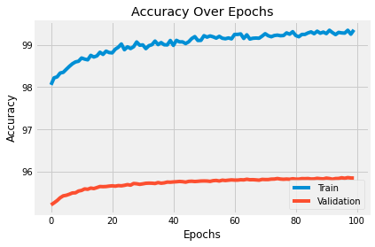

```python
plt.plot(np.array(history8.history['accuracy']) * 100)
plt.plot(np.array(history8.history['val_accuracy']) * 100)
plt.ylabel('Accuracy')
plt.xlabel('Epochs')
plt.legend(['Train', 'Validation'])
plt.title('Accuracy Over Epochs')
plt.show()
```

```python
results1 = keras_model3.evaluate(X_val, y_val)

df_temp = pd.DataFrame({'Method':['NN, SGD, RELU, Batch, LR=0.001'], 'Validation Accuracy':
                        [results1[1]], 'Test Accuracy':[0.0]}, index={'8'})
df_result = pd.concat([df_temp, df_result])
df_result
```

|  | Method | Validation Accuracy | Test Accuracy |
| --- | --- | --- | --- |
| 8 | NN, SGD, RELU, Batch, LR=0.001 | 0.958533 | 0.0 |
| 7 | NN, Adam, RELU, Batch, LR=0.001 | 0.879967 | 0.0 |
| 6 | NN, Adam, RELU, LR=0.001 | 0.100000 | 0.0 |
| 5 | NN, Adam, RELU, LR=0.01 | 0.100000 | 0.0 |
| 4 | NN, SGD, RELU, LR=0.001 | 0.864817 | 0.0 |
| 3 | NN, SGD, RELU, LR=0.01 | 0.829583 | 0.0 |
| 2 | NN, SGD, Sigmoid, LR=0.001 | 0.100000 | 0.0 |
| 1 | NN, SGD, Sigmoid, LR=0.01 | 0.100000 | 0.0 |

#### Observations

- The batch normalization using SGD optimizer is giving better results than using Adam optimizer.
- Also, result produced by Model shows the sign of overfit.
- Next, let's try droping some of the weak neurons.

### Implementing Batch Normalization and Dropout for training the neural network

```python
#Initialize the Artificial Neural Network Classifier
keras_model4 = Sequential()
```

```python
#==============
#Input Layer
#==============
#Adding Input layer and activation functions ReLU
keras_model4.add(Dense(512, kernel_initializer='he_normal',input_shape = (1024, )))
#Adding BatchNormalization Layer
keras_model4.add(BatchNormalization())
#Adding Activation function
keras_model4.add(Activation('relu'))
#Adding Dropout Layer
keras_model4.add(Dropout(0.2))

#==============
#Hidden Layer1
#==============
#Adding first Hidden layer
keras_model4.add(Dense(256,kernel_initializer='he_normal'))
#Adding BatchNormalization Layer
keras_model4.add(BatchNormalization())
#Adding Activation function
keras_model4.add(Activation('relu'))
#Adding Dropout Layer
keras_model4.add(Dropout(0.2))

#==============
#Hidden Layer2
#==============
#Adding second Hidden layer
keras_model4.add(Dense(128, kernel_initializer='he_normal'))
#Adding BatchNormalization Layer
keras_model4.add(BatchNormalization())
#Adding Activation function
keras_model4.add(Activation('relu'))
#Adding Dropout Layer
keras_model4.add(Dropout(0.2))

#==============
#Hidden Layer3
#==============
#Adding third Hidden layer
keras_model4.add(Dense(64, kernel_initializer='he_normal'))
#Adding BatchNormalization Layer
keras_model4.add(BatchNormalization())
#Adding Activation function
keras_model4.add(Activation('relu'))
#Adding Dropout Layer
keras_model4.add(Dropout(0.2))

#==============
#Hidden Layer4
#==============
#Adding fourth Hidden layer
keras_model4.add(Dense(32, kernel_initializer='he_normal'))
#Adding BatchNormalization Layer
keras_model4.add(BatchNormalization())
#Adding Activation function
keras_model4.add(Activation('relu'))
#Adding Dropout Layer
keras_model4.add(Dropout(0.2))

#==============
#Output Layer
#==============
#Adding output layer which is of 10 nodes (digidts)
keras_model4.add(Dense(10))
#Adding Activation function
# Here, we are using softmax function because we have multiclass classsification
keras_model4.add(Activation('softmax'))
```

```python
#Model Summary
keras_model4.summary()
```

```
Model: "sequential_4"
_________________________________________________________________
Layer (type)                 Output Shape              Param #
=================================================================
dense_19 (Dense)             (None, 512)               524800
_________________________________________________________________
batch_normalization_6 (Batch (None, 512)               2048
_________________________________________________________________
activation_19 (Activation)   (None, 512)               0
_________________________________________________________________
dropout_1 (Dropout)          (None, 512)               0
_________________________________________________________________
dense_20 (Dense)             (None, 256)               131328
_________________________________________________________________
batch_normalization_7 (Batch (None, 256)               1024
_________________________________________________________________
activation_20 (Activation)   (None, 256)               0
_________________________________________________________________
dropout_2 (Dropout)          (None, 256)               0
_________________________________________________________________
dense_21 (Dense)             (None, 128)               32896
_________________________________________________________________
batch_normalization_8 (Batch (None, 128)               512
_________________________________________________________________
activation_21 (Activation)   (None, 128)               0
_________________________________________________________________
dropout_3 (Dropout)          (None, 128)               0
_________________________________________________________________
dense_22 (Dense)             (None, 64)                8256
_________________________________________________________________
batch_normalization_9 (Batch (None, 64)                256
_________________________________________________________________
activation_22 (Activation)   (None, 64)                0
_________________________________________________________________
dropout_4 (Dropout)          (None, 64)                0
_________________________________________________________________
dense_23 (Dense)             (None, 32)                2080
_________________________________________________________________
batch_normalization_10 (Batc (None, 32)                128
_________________________________________________________________
activation_23 (Activation)   (None, 32)                0
_________________________________________________________________
dropout_5 (Dropout)          (None, 32)                0
_________________________________________________________________
dense_24 (Dense)             (None, 10)                330
_________________________________________________________________
activation_24 (Activation)   (None, 10)                0
=================================================================
Total params: 703,658
Trainable params: 701,674
Non-trainable params: 1,984
_________________________________________________________________
```

```python
#Setting the learning rate in Adam
adam = optimizers.Adam(lr = 0.001)
# compiling the ANN classifier
keras_model4.compile(optimizer=adam, loss='categorical_crossentropy', metrics=['accuracy'])
# Fitting the ANN to the Training data
history9 = keras_model4.fit(X_train, y_train, validation_data=(X_val,y_val), batch_size=100, epochs=100, verbose=1)
```

```
Train on 42000 samples, validate on 60000 samples
```

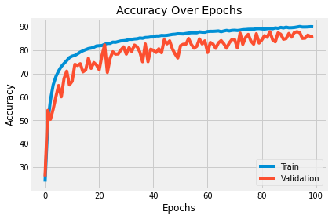

```python
plt.plot(np.array(history9.history['accuracy']) * 100)
plt.plot(np.array(history9.history['val_accuracy']) * 100)
plt.ylabel('Accuracy')
plt.xlabel('Epochs')
plt.legend(['Train', 'Validation'])
plt.title('Accuracy Over Epochs')
plt.show()
```

```python
results1 = keras_model4.evaluate(X_val, y_val)

df_temp = pd.DataFrame({'Method':['NN, Adam, RELU, Batch, Drop=0.2, LR=0.001'], 'Validation Accuracy':
                        [results1[1]], 'Test Accuracy':[0.0]}, index={'9'})
df_result = pd.concat([df_temp, df_result])
df_result
```

|  | Method | Validation Accuracy | Test Accuracy |
| --- | --- | --- | --- |
| 9 | NN, Adam, RELU, Batch, Drop=0.2, LR=0.001 | 0.859367 | 0.0 |
| 8 | NN, SGD, RELU, Batch, LR=0.001 | 0.958533 | 0.0 |
| 7 | NN, Adam, RELU, Batch, LR=0.001 | 0.879967 | 0.0 |
| 6 | NN, Adam, RELU, LR=0.001 | 0.100000 | 0.0 |
| 5 | NN, Adam, RELU, LR=0.01 | 0.100000 | 0.0 |
| 4 | NN, SGD, RELU, LR=0.001 | 0.864817 | 0.0 |
| 3 | NN, SGD, RELU, LR=0.01 | 0.829583 | 0.0 |
| 2 | NN, SGD, Sigmoid, LR=0.001 | 0.100000 | 0.0 |
| 1 | NN, SGD, Sigmoid, LR=0.01 | 0.100000 | 0.0 |

```python
#Setting the learning rate in Adam
sgd = optimizers.SGD(lr = 0.001)
# compiling the ANN classifier
keras_model4.compile(optimizer=sgd, loss='categorical_crossentropy', metrics=['accuracy'])
# Fitting the ANN to the Training data
history10 = keras_model4.fit(X_train, y_train, validation_data=(X_val,y_val), batch_size=100, epochs=100, verbose=1)
```

```
Train on 42000 samples, validate on 60000 samples
```

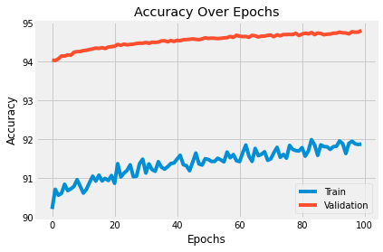

```python
plt.plot(np.array(history10.history['accuracy']) * 100)
plt.plot(np.array(history10.history['val_accuracy']) * 100)
plt.ylabel('Accuracy')
plt.xlabel('Epochs')
plt.legend(['Train', 'Validation'])
plt.title('Accuracy Over Epochs')
plt.show()
```

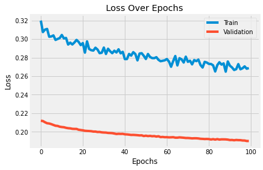

```python
plt.plot(np.array(history10.history['loss']))
plt.plot(np.array(history10.history['val_loss']))
plt.ylabel('Loss')
plt.xlabel('Epochs')
plt.legend(['Train', 'Validation'])
plt.title('Loss Over Epochs')
plt.show()
```

```python
results1 = keras_model4.evaluate(X_val, y_val)

df_temp = pd.DataFrame({'Method':['NN, SGD, RELU, Batch, Drop=0.2, LR=0.001'], 'Validation Accuracy':
                        [results1[1]], 'Test Accuracy':[0.0]}, index={'10'})
df_result = pd.concat([df_temp, df_result])
df_result
```

|  | Method | Validation Accuracy | Test Accuracy |
| --- | --- | --- | --- |
| 10 | NN, SGD, RELU, Batch, Drop=0.2, LR=0.001 | 0.948067 | 0.0 |
| 9 | NN, Adam, RELU, Batch, Drop=0.2, LR=0.001 | 0.859367 | 0.0 |
| 8 | NN, SGD, RELU, Batch, LR=0.001 | 0.958533 | 0.0 |
| 7 | NN, Adam, RELU, Batch, LR=0.001 | 0.879967 | 0.0 |
| 6 | NN, Adam, RELU, LR=0.001 | 0.100000 | 0.0 |
| 5 | NN, Adam, RELU, LR=0.01 | 0.100000 | 0.0 |
| 4 | NN, SGD, RELU, LR=0.001 | 0.864817 | 0.0 |
| 3 | NN, SGD, RELU, LR=0.01 | 0.829583 | 0.0 |
| 2 | NN, SGD, Sigmoid, LR=0.001 | 0.100000 | 0.0 |
| 1 | NN, SGD, Sigmoid, LR=0.01 | 0.100000 | 0.0 |

#### Observations

- With drop at 0.2, SGD is giving better results than Adam.
- Also, train and validation results are in sync.
- Next, lets use the NN Model with SGD optimizer, RELU Activation, Batch, Drop=0.2, and LR=0.001.
- Check it against the test data set and compare the performance.

### Testing NN on Test Data

```python
results_final1 = keras_model4.evaluate(X_val, y_val)
results_final2 = keras_model4.evaluate(X_test, y_test)

df_temp = pd.DataFrame({'Method':['Final Model: NN, SGD, RELU, Batch, Drop=0.2, LR=0.001'], 'Validation Accuracy':
                        [results_final1[1]], 'Test Accuracy':[results_final2[1]]}, index={'11'})
df_result = pd.concat([df_temp, df_result])
df_result
```

|  | Method | Validation Accuracy | Test Accuracy |
| --- | --- | --- | --- |
| 11 | Final Model: NN, SGD, RELU, Batch, Drop=0.2, L... | 0.948067 | 0.884833 |
| 10 | NN, SGD, RELU, Batch, Drop=0.2, LR=0.001 | 0.948067 | 0.000000 |
| 9 | NN, Adam, RELU, Batch, Drop=0.2, LR=0.001 | 0.859367 | 0.000000 |
| 8 | NN, SGD, RELU, Batch, LR=0.001 | 0.958533 | 0.000000 |
| 7 | NN, Adam, RELU, Batch, LR=0.001 | 0.879967 | 0.000000 |
| 6 | NN, Adam, RELU, LR=0.001 | 0.100000 | 0.000000 |
| 5 | NN, Adam, RELU, LR=0.01 | 0.100000 | 0.000000 |
| 4 | NN, SGD, RELU, LR=0.001 | 0.864817 | 0.000000 |
| 3 | NN, SGD, RELU, LR=0.01 | 0.829583 | 0.000000 |
| 2 | NN, SGD, Sigmoid, LR=0.001 | 0.100000 | 0.000000 |
| 1 | NN, SGD, Sigmoid, LR=0.01 | 0.100000 | 0.000000 |

#### Predicting the digits using NN classifier on test data

##### Image 1

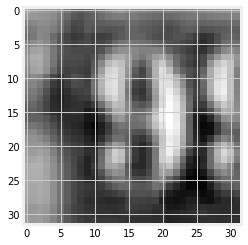

```python
#Showing the image
plt.imshow(X_test[5].reshape(32,32),cmap='gray')
```

```python
#Predicting the digits
keras_model4.predict_classes(X_test)[5]
```

```
9
```

###### Image 2

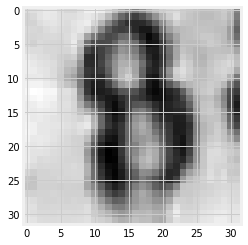

```python
#Showing the image
plt.imshow(X_test[10].reshape(32,32),cmap='gray')
```

```python
#Predicting the digits
keras_model4.predict_classes(X_test)[10]
```

```
8
```

##### Image 3

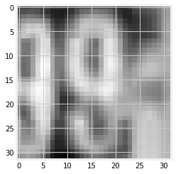

```python
#Showing the image
plt.imshow(X_test[112].reshape(32,32),cmap='gray')
```

```python
#Predicting the digits
keras_model4.predict_classes(X_test)[112]
```

```
9
```

```python
#Predicting for all images
y_pred = keras_model4.predict_classes(X_test)
print(y_pred)
```

```
[1 7 2 ... 7 9 2]
```

## Step 6 - Print the classification accuracy metrics (10 points)

```python
rounded_predictions = keras_model4.predict_classes(X_test, batch_size=128, verbose=0)
rounded_predictions[1]
```

```
7
```

```python
rounded_labels = np.argmax(y_test, axis=1)
rounded_labels[1]
```

```
7
```

```python
cm = metrics.confusion_matrix(rounded_labels, rounded_predictions)
print(cm)
```

```
[[1657   27   12   23   13    7   14   15   14   32]
 [  24 1651   11   22   41    8    6   38   16   11]
 [  14   22 1596   30   19   13    4   51   24   30]
 [  12   27   21 1455   15   95   14   19   42   19]
 [  20   40   13   20 1646   10   13    8   16   26]
 [  10   16   14   66   10 1548   46   12   27   19]
 [  35   12   11   22   21   47 1595   11   65   13]
 [  12   47   25   19   14    6   11 1656    6   12]
 [  28   32   12   38   10   25   60    9 1554   44]
 [  45   28   17   29   13   38   10   16   39 1569]]
```

```python
cr=metrics.classification_report(rounded_labels, rounded_predictions)
print(cr)
```

```
              precision    recall  f1-score   support

           0       0.89      0.91      0.90      1814
           1       0.87      0.90      0.89      1828
           2       0.92      0.89      0.90      1803
           3       0.84      0.85      0.85      1719
           4       0.91      0.91      0.91      1812
           5       0.86      0.88      0.87      1768
           6       0.90      0.87      0.88      1832
           7       0.90      0.92      0.91      1808
           8       0.86      0.86      0.86      1812
           9       0.88      0.87      0.88      1804

    accuracy                           0.88     18000
   macro avg       0.88      0.88      0.88     18000
weighted avg       0.89      0.88      0.88     18000
```